# Project Machine Learning: AllLife Bank Data Analysis by Gabriel Hinojos

# **Problem Statement**

### Context

AllLife Bank is a US bank that has a growing customer base. The majority of these customers are liability customers (depositors) with varying sizes of deposits. The number of customers who are also borrowers (asset customers) is quite small, and the bank is interested in expanding this base rapidly to bring in more loan business and in the process, earn more through the interest on loans. In particular, the management wants to explore ways of converting its liability customers to personal loan customers (while retaining them as depositors).

A campaign that the bank ran last year for liability customers showed a healthy conversion rate of over 9% success. This has encouraged the retail marketing department to devise campaigns with better target marketing to increase the success ratio.

You as a Data scientist at AllLife bank have to build a model that will help the marketing department to identify the potential customers who have a higher probability of purchasing the loan.

### Objective

To predict whether a liability customer will buy personal loans, to understand which customer attributes are most significant in driving purchases, and identify which segment of customers to target more.

### Data Dictionary

- `ID`: Customer ID
- `Age`: Customer’s age in completed years
- `Experience`: #years of professional experience
- `Income`: Annual income of the customer (in thousand dollars)
- `ZIP Code`: Home Address ZIP code.
- `Family`: the Family size of the customer
- `CCAvg`: Average spending on credit cards per month (in thousand dollars)
- `Education`: Education Level. 1: Undergrad; 2: Graduate;3: Advanced/Professional
- `Mortgage`: Value of house mortgage if any. (in thousand dollars)
- `Personal_Loan`: Did this customer accept the personal loan offered in the last campaign? (0: No, 1: Yes)
- `Securities_Account`: Does the customer have securities account with the bank? (0: No, 1: Yes)
- `CD_Account`: Does the customer have a certificate of deposit (CD) account with the bank? (0: No, 1: Yes)
- `Online`: Do customers use internet banking facilities? (0: No, 1: Yes)
- `CreditCard`: Does the customer use a credit card issued by any other Bank (excluding All life Bank)? (0: No, 1: Yes)

# **Importing necessary libraries**

```python
# Commented out this section as this is run in Google Colab
# Installing the libraries with the specified version.
# !pip install numpy==1.25.2 pandas==1.5.3 matplotlib==3.7.1 seaborn==0.13.1 scikit-learn==1.2.2 sklearn-pandas==2.2.0 -q --user
```

**Note**:

1. After running the above cell, kindly restart the notebook kernel (for Jupyter Notebook) or runtime (for Google Colab), write the relevant code for the project from the next cell, and run all cells sequentially from the next cell.
2. On executing the above line of code, you might see a warning regarding package dependencies. This error message can be ignored as the above code ensures that all necessary libraries and their dependencies are maintained to successfully execute the code in this notebook.

```python
# import libraries for reading an manipulation of data
import pandas as pd
import numpy as np


# import libraries for data visualization
import seaborn as sns
import matplotlib.pyplot as plt

# import library to split the data into train and test
from sklearn.model_selection import train_test_split

# import library to build linear regression_model
from sklearn.linear_model import LinearRegression

# import library to check model performance
from sklearn.metrics import mean_absolute_error, mean_squared_error, r2_score

# import libraries to build decision tree model
from sklearn.tree import DecisionTreeClassifier
from sklearn import tree

# import library to tune different models
from sklearn.model_selection import GridSearchCV

# import library to compute classification metrics
from sklearn.metrics import (
    confusion_matrix,
    accuracy_score,
    recall_score,
    precision_score,
    f1_score,
)

# import library to suppress unnecessary warnings
import warnings
warnings.filterwarnings("ignore")
```

# **Loading the dataset**

```python
# run the following lines for Google Colab
from google.colab import drive
drive.mount('/content/drive')
```

```python
# read the dataset from the Google Colab drive Python Course
loans = pd.read_csv('/content/drive/MyDrive/Python Course/Loan_Modelling.csv')
```

```python
# creating a copy of the data
data = loans.copy()
```

# **Data Overview**

## Viewing the first and last 5 rows of the dataset

```python
# pull the first 5 rows of data from dataset
data.head(5)
```

|  | ID | Age | Experience | Income | ZIPCode | Family | CCAvg | Education | Mortgage | Personal_Loan | Securities_Account | CD_Account | Online | CreditCard |
| --- | --- | --- | --- | --- | --- | --- | --- | --- | --- | --- | --- | --- | --- | --- |
| 0 | 1 | 25 | 1 | 49 | 91107 | 4 | 1.6 | 1 | 0 | 0 | 1 | 0 | 0 | 0 |
| 1 | 2 | 45 | 19 | 34 | 90089 | 3 | 1.5 | 1 | 0 | 0 | 1 | 0 | 0 | 0 |
| 2 | 3 | 39 | 15 | 11 | 94720 | 1 | 1.0 | 1 | 0 | 0 | 0 | 0 | 0 | 0 |
| 3 | 4 | 35 | 9 | 100 | 94112 | 1 | 2.7 | 2 | 0 | 0 | 0 | 0 | 0 | 0 |
| 4 | 5 | 35 | 8 | 45 | 91330 | 4 | 1.0 | 2 | 0 | 0 | 0 | 0 | 0 | 1 |

```python
# pull the last 5 rows of the data from the dataset
data.tail(5)
```

|  | ID | Age | Experience | Income | ZIPCode | Family | CCAvg | Education | Mortgage | Personal_Loan | Securities_Account | CD_Account | Online | CreditCard |
| --- | --- | --- | --- | --- | --- | --- | --- | --- | --- | --- | --- | --- | --- | --- |
| 4995 | 4996 | 29 | 3 | 40 | 92697 | 1 | 1.9 | 3 | 0 | 0 | 0 | 0 | 1 | 0 |
| 4996 | 4997 | 30 | 4 | 15 | 92037 | 4 | 0.4 | 1 | 85 | 0 | 0 | 0 | 1 | 0 |
| 4997 | 4998 | 63 | 39 | 24 | 93023 | 2 | 0.3 | 3 | 0 | 0 | 0 | 0 | 0 | 0 |
| 4998 | 4999 | 65 | 40 | 49 | 90034 | 3 | 0.5 | 2 | 0 | 0 | 0 | 0 | 1 | 0 |
| 4999 | 5000 | 28 | 4 | 83 | 92612 | 3 | 0.8 | 1 | 0 | 0 | 0 | 0 | 1 | 1 |

## Checking the shape of the dataset

```python
# view the number of rows and columns that are present in the data
data.shape
```

```
(5000, 14)
```

Observations: The dataset has 5000 rows and 14 columns

## Checking the attribute types

```python
# pull the datatypes for each column and entries for each column in the dataset
data.info()
```

```
<class 'pandas.core.frame.DataFrame'>
RangeIndex: 5000 entries, 0 to 4999
Data columns (total 14 columns):
 #   Column              Non-Null Count  Dtype
---  ------              --------------  -----
 0   ID                  5000 non-null   int64
 1   Age                 5000 non-null   int64
 2   Experience          5000 non-null   int64
 3   Income              5000 non-null   int64
 4   ZIPCode             5000 non-null   int64
 5   Family              5000 non-null   int64
 6   CCAvg               5000 non-null   float64
 7   Education           5000 non-null   int64
 8   Mortgage            5000 non-null   int64
 9   Personal_Loan       5000 non-null   int64
 10  Securities_Account  5000 non-null   int64
 11  CD_Account          5000 non-null   int64
 12  Online              5000 non-null   int64
 13  CreditCard          5000 non-null   int64
dtypes: float64(1), int64(13)
memory usage: 547.0 KB
```

Observations: All datatypes with the excpetion of CCAvg is 'int64(integer).' The following column datatype is 'float64(float)': CCAvg. There were no missing values identified as shown in the info view.

## Checking the statistical summary

```python
# check the statistical information for each varaiable (column) in the dataset
data.describe().T
```

|  | count | mean | std | min | 25% | 50% | 75% | max |
| --- | --- | --- | --- | --- | --- | --- | --- | --- |
| ID | 5000.0 | 2500.500000 | 1443.520003 | 1.0 | 1250.75 | 2500.5 | 3750.25 | 5000.0 |
| Age | 5000.0 | 45.338400 | 11.463166 | 23.0 | 35.00 | 45.0 | 55.00 | 67.0 |
| Experience | 5000.0 | 20.104600 | 11.467954 | -3.0 | 10.00 | 20.0 | 30.00 | 43.0 |
| Income | 5000.0 | 73.774200 | 46.033729 | 8.0 | 39.00 | 64.0 | 98.00 | 224.0 |
| ZIPCode | 5000.0 | 93169.257000 | 1759.455086 | 90005.0 | 91911.00 | 93437.0 | 94608.00 | 96651.0 |
| Family | 5000.0 | 2.396400 | 1.147663 | 1.0 | 1.00 | 2.0 | 3.00 | 4.0 |
| CCAvg | 5000.0 | 1.937938 | 1.747659 | 0.0 | 0.70 | 1.5 | 2.50 | 10.0 |
| Education | 5000.0 | 1.881000 | 0.839869 | 1.0 | 1.00 | 2.0 | 3.00 | 3.0 |
| Mortgage | 5000.0 | 56.498800 | 101.713802 | 0.0 | 0.00 | 0.0 | 101.00 | 635.0 |
| Personal_Loan | 5000.0 | 0.096000 | 0.294621 | 0.0 | 0.00 | 0.0 | 0.00 | 1.0 |
| Securities_Account | 5000.0 | 0.104400 | 0.305809 | 0.0 | 0.00 | 0.0 | 0.00 | 1.0 |
| CD_Account | 5000.0 | 0.060400 | 0.238250 | 0.0 | 0.00 | 0.0 | 0.00 | 1.0 |
| Online | 5000.0 | 0.596800 | 0.490589 | 0.0 | 0.00 | 1.0 | 1.00 | 1.0 |
| CreditCard | 5000.0 | 0.294000 | 0.455637 | 0.0 | 0.00 | 0.0 | 1.00 | 1.0 |

## Checking for missing values

```python
# check data for any records with no data entered for the column
data.isnull().sum()
```

|  | 0 |
| --- | --- |
| ID | 0 |
| Age | 0 |
| Experience | 0 |
| Income | 0 |
| ZIPCode | 0 |
| Family | 0 |
| CCAvg | 0 |
| Education | 0 |
| Mortgage | 0 |
| Personal_Loan | 0 |
| Securities_Account | 0 |
| CD_Account | 0 |
| Online | 0 |
| CreditCard | 0 |

**dtype:** int64

Observations: There are no null values in the dataset.

## Checking for duplicate values

```python
# check for duplicate values in the dataset
data.duplicated().sum()
```

```
np.int64(0)
```

Observations: There are no duplicates in the data.

```python
data['ID'].nunique()
```

```
5000
```

```python
# drop the ID feature as each ID is unique and it is not needed for data analysis
data = data.drop(['ID'], axis=1)
```

## Checking Experience variable

```python
# check Experience data for unique values
data['Experience'].unique()
```

```
array([ 1, 19, 15,  9,  8, 13, 27, 24, 10, 39,  5, 23, 32, 41, 30, 14, 18,
       21, 28, 31, 11, 16, 20, 35,  6, 25,  7, 12, 26, 37, 17,  2, 36, 29,
        3, 22, -1, 34,  0, 38, 40, 33,  4, -2, 42, -3, 43])
```

Observations: There are 47 unique values for years of professional experience

```python
# check Experience data for unique values less than 0
data[data['Experience'] <0]['Experience'].unique()
```

```
array([-1, -2, -3])
```

Observations: There are 3 unique values for years of professional experience listed as negative values

```python
# update experience values to positive values
data['Experience'].replace(-1, 1, inplace=True)
data['Experience'].replace(-2, 2, inplace=True)
data['Experience'].replace(-3, 3, inplace=True)
```

```python
# re-check Experience data for unique values
data['Experience'].nunique()
```

```
44
```

Observations: There are 44 unique values for years of professional experience with the removal of the negative values.

## Convert Zip Code to truncated string variable

```python
# truncating the Zip code to the first two characters so that can better handle in data analysis
data["ZIPCode"] = data["ZIPCode"].astype(str)
data["ZIPCode"] = data["ZIPCode"].str[:2]
```

## Convert integer variables to category variables

```python
# Converting the integer data types to category data types
data['ZIPCode'] = data['ZIPCode'].astype('category')
data['Family'] = data['Family'].astype('category')
data['Education'] = data['Education'].astype('category')
data['Personal_Loan'] = data['Personal_Loan'].astype('category')
data['Securities_Account'] = data['Securities_Account'].astype('category')
data['CD_Account'] = data['CD_Account'].astype('category')
data['Online'] = data['Online'].astype('category')
data['Personal_Loan'] = data['Personal_Loan'].astype('category')
data['CreditCard'] = data['CreditCard'].astype('category')
```

# **Exploratory Data Analysis**

- EDA is an important part of any project involving data.
- It is important to investigate and understand the data better before building a model with it.
- A few questions have been mentioned below which will help you approach the analysis in the right manner and generate insights from the data.
- A thorough analysis of the data, in addition to the questions mentioned below, should be done.

## Define Functions used for EDA

```python
# setup function to create combined boxplot and histogram for univariate analysis of numerical variables in dataset
# data - dataframe dataset; feature - column in dataset; figsize - figure size; kde - density curve displayed; bins - interval of groups in the histogram
def histogram_boxplot(data, feature, figsize=(20, 10), kde=False, bins=None):
    # create the subplots
    # nrows - Number of rows in the subplot grid; sharex - x-axis will be shared among all subplots
    f2, (ax_box2, ax_hist2) = plt.subplots(nrows=2, sharex=True, gridspec_kw={"height_ratios": (0.25, 0.75)}, figsize=figsize,)
    # create the boxplot which will display a triangle to indicate the mean value of the variable
    sns.boxplot(data=data, x=feature, ax=ax_box2, showmeans=True, color="aquamarine")
    # create the histogram which will display a straight line for the mean of the variable and dotted line for the median of the variable
    sns.histplot(data=data, x=feature, kde=kde, ax=ax_hist2, bins=bins,
    ) if bins else sns.histplot(
        data=data, x=feature, kde=kde, ax=ax_hist2, color="violet")
    ax_hist2.axvline(data[feature].mean(), color="black", linestyle="--")
    ax_hist2.axvline(data[feature].median(), color="gold", linestyle="-")
```

```python
# setup function to create barplot with the percentage on top for univariate analysis of category variables in dataset
# data - dataframe dataset; feature - column in dataset; perc - display of percentages instead of count (set to False);
# n - display the top n category levels (set to display all levels)
def labeled_barplot(data, feature, perc=False, n=None):
    total = len(data[feature])  # length of the column
    count = data[feature].nunique()
    if n is None:
        plt.figure(figsize=(count + 2, 6))
    else:
        plt.figure(figsize=(n + 2, 6))

    plt.xticks(rotation=90, fontsize=15)
    ax = sns.countplot(data=data, x=feature, palette="pastel",
        order=data[feature].value_counts().index[:n],)
    # set percentage of each class of category, count of each category,
    # set width and height of the plot
    for p in ax.patches:
        if perc == True:
            label = "{:.1f}%".format(100 * p.get_height() / total)
        else:
            label = p.get_height()

        x = p.get_x() + p.get_width() / 2
        y = p.get_height()
        # annotate the percentage
        ax.annotate(label, (x, y), ha="center", va="center",
            size=12, xytext=(0, 5), textcoords="offset points",)

    plt.show()
```

```python
# setup function to create category counts and plot a stacked bar chart for bivariate analysis of variables in dataset
# data - dataframe dataset; predictor - independent variable, target - target variable
def stacked_barplot(data, predictor, target):
    count = data[predictor].nunique()
    sorter = data[target].value_counts().index[-1]
    tab1 = pd.crosstab(data[predictor], data[target], margins=True).sort_values(
        by=sorter, ascending=False)
    print(tab1)
    print("-" * 120)
    tab = pd.crosstab(data[predictor], data[target], normalize="index").sort_values(
        by=sorter, ascending=False)
    tab.plot(kind="bar", stacked=True, figsize=(count + 5, 5))
    plt.legend(loc="lower left", frameon=False,)
    plt.legend(loc="upper left", bbox_to_anchor=(1, 1))
    plt.show()
```

```python
# setup function to plot distribution with respect to (wrt) a target variable (Personal Loan for this dataframe)
# data - dataframe dataset; predictor - independent variable, target - target variable
def distribution_plot_wrt_target(data, predictor, target):

    fig, axs = plt.subplots(2, 2, figsize=(12, 10))

    target_uniq = data[target].unique()

    axs[0, 0].set_title("Distribution of target for target=" + str(target_uniq[0]))
    sns.histplot(data=data[data[target] == target_uniq[0]], x=predictor,
        kde=True, ax=axs[0, 0], color="goldenrod", stat="density",)

    axs[0, 1].set_title("Distribution of target for target=" + str(target_uniq[1]))
    sns.histplot(data=data[data[target] == target_uniq[1]], x=predictor,
        kde=True, ax=axs[0, 1], color="navy", stat="density",)

    axs[1, 0].set_title("Boxplot w.r.t target")
    sns.boxplot(data=data, x=target, y=predictor, ax=axs[1, 0], palette='plasma')

    axs[1, 1].set_title("Boxplot (without outliers) w.r.t target")
    sns.boxplot(data=data, x=target, y=predictor, ax=axs[1, 1],
        showfliers=False, palette='plasma',)

    plt.tight_layout()
    plt.show()
```

## Univariate Analysis

**Variable Age Observation**

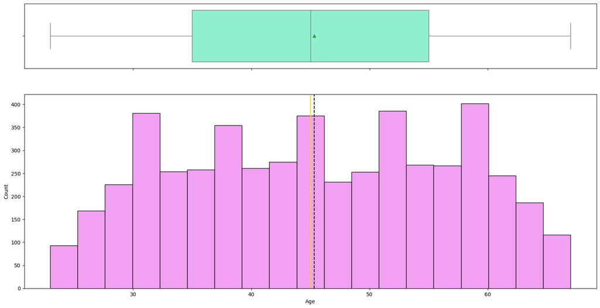

```python
histogram_boxplot(data, 'Age')
```

Observations: The Age distribution looks equally distributed with no outliers present. The avarage age of the dataset is 45 years.

**Variable Experience Observation**

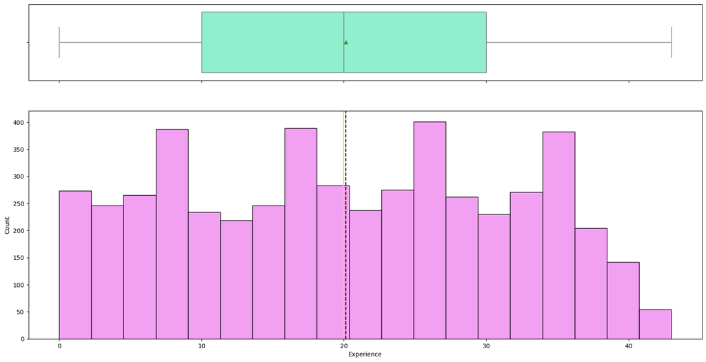

```python
histogram_boxplot(data, 'Experience')
```

Observations: The Experience distribution looks equally distributed with no outliers present. The avarage years of professional experience of the dataset is 20 years.

**Variable Income Observation**

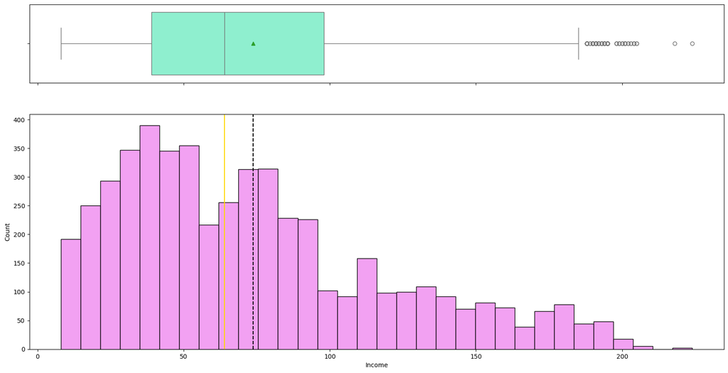

```python
histogram_boxplot(data, 'Income')
```

**Variable Credit Card Average Spending Observation**

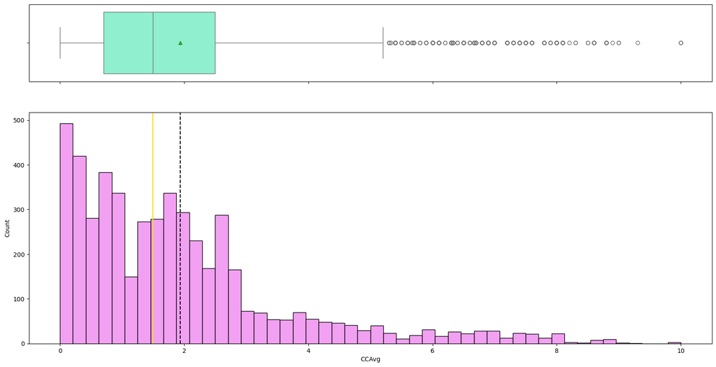

```python
histogram_boxplot(data, 'CCAvg')
```

**Variable Mortgage Observation**

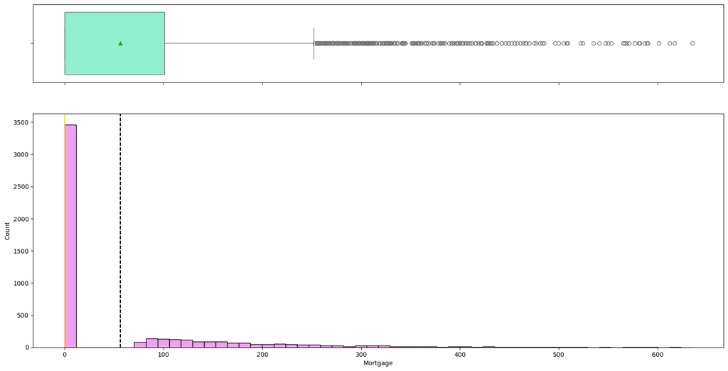

```python
histogram_boxplot(data, 'Mortgage')
```

Observations: The value of the home mortgage distribution is heavily right skewed with all of the outliers in the upper quartile. The majority of the dataset does not have a mortgage value.

**Variable Zip Code Observation**

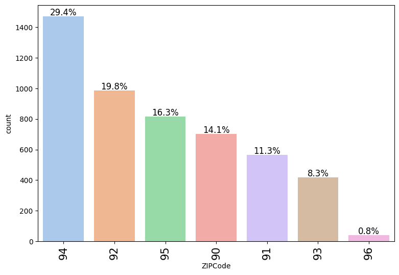

```python
labeled_barplot(data, 'ZIPCode', perc=True)
```

Observations: The majority of customers that were offered personal loans were in the area code starting with 94xxx (29.4%) while 92xxx (19.8%) and 95xxx (16.3%) round out the top three.

**Variable Education Observation**

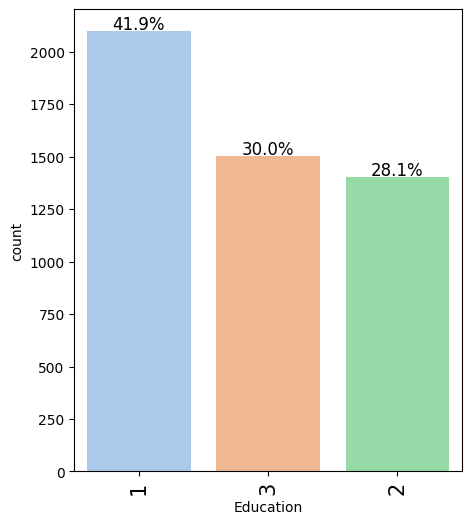

```python
labeled_barplot(data, 'Education', perc=True)
```

Observations: A larger percentage of customers with an undergrad education (41.9%) were in the last campaign.

**Variable Family Observation**

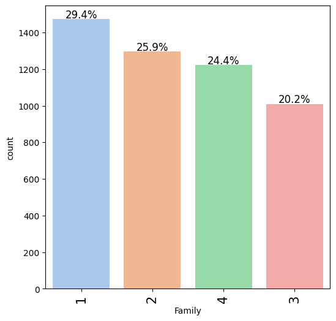

```python
# create a countplot to visualize the distribution of size of the family for the customer
labeled_barplot(data, 'Family', perc=True)
```

Observations: A larger percentage of single customers (29.4%) were in the last campaign followed by customers with partners or other person their house at 25.9%

**Variable Personal Loan Observation**

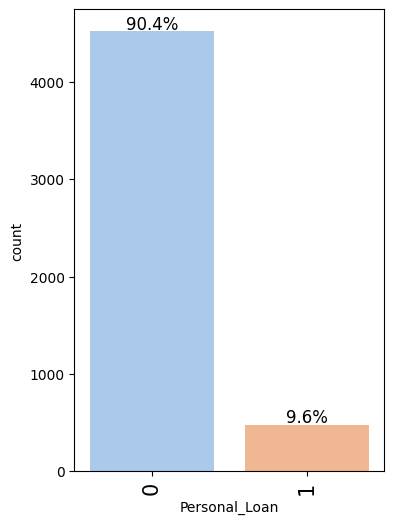

```python
# create a countplot to visualize the distribution of whether the customer accepted the personal loan offered in the last campaign
labeled_barplot(data, 'Personal_Loan',perc=True)
```

Observations: A very large percentage of the customers (90.4%) to not accept the personal loan in the last campaign.

**Variable Securities Account Observation**

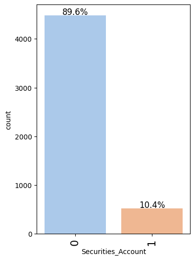

```python
# create a countplot to visualize the distribution of whether the customer has security account with the bank
labeled_barplot(data, 'Securities_Account',perc=True)
```

**Variable CD Account Observation**

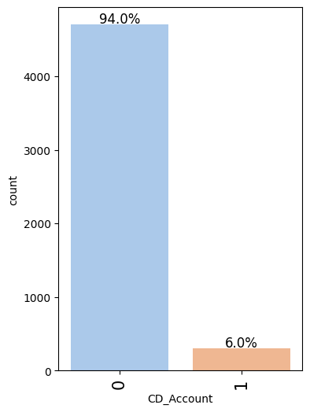

```python
# create a countplot to visualize the distribution of whether the customer has Certificate of Deposit (CD) with the bank
labeled_barplot(data, 'CD_Account',perc=True)
```

**Variable Online Observation**

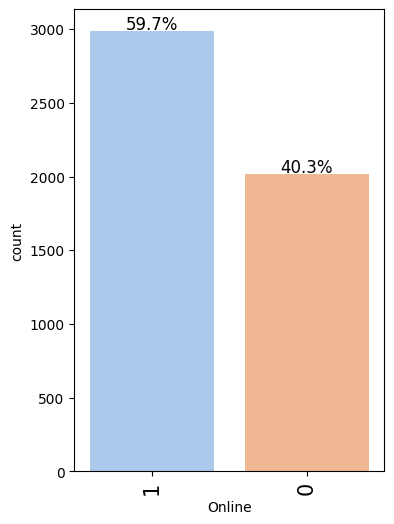

```python
# create a countplot to visualize the distribution of customers using internet banking
labeled_barplot(data, 'Online',perc=True)
```

Observations: A majority of the customers (59.7%) that use internet banking facilities were in the last campaign.

**Variable Credit Card Observation**

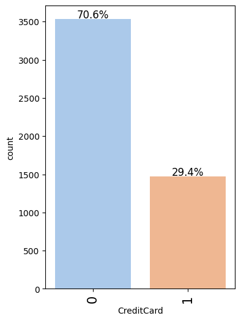

```python
# create a countplot to visualize the distribution of Credit card issued by another bank
labeled_barplot(data, 'CreditCard',perc=True)
```

## Bivariate Analysis

**Analysis of the correlation of variables in the dataset**

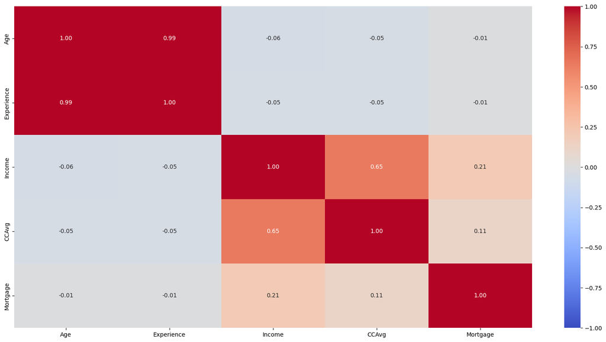

```python
# create a heatmap for the correlation of the numeric features
cols_list = data.select_dtypes(include=np.number).columns.tolist()
plt.figure(figsize=(20, 10))
sns.heatmap(
    data[cols_list].corr(), annot=True, vmin=-1, vmax=1, fmt=".2f", cmap='coolwarm'
)
plt.show()
```

Observations:

- There is very strong positive correlation between Age and Experience
- There is a strong positive correlation between CCAvg (average spending on credit cards per month) and Income of the customer.
- There is a positive correlation between Income and value of Mortgage.
- There is a weak positive correlation between CCAvg and Mortgage.
- All other variables do not appear to be correlated.

**Analysis of Personal Loan vs Age variables**

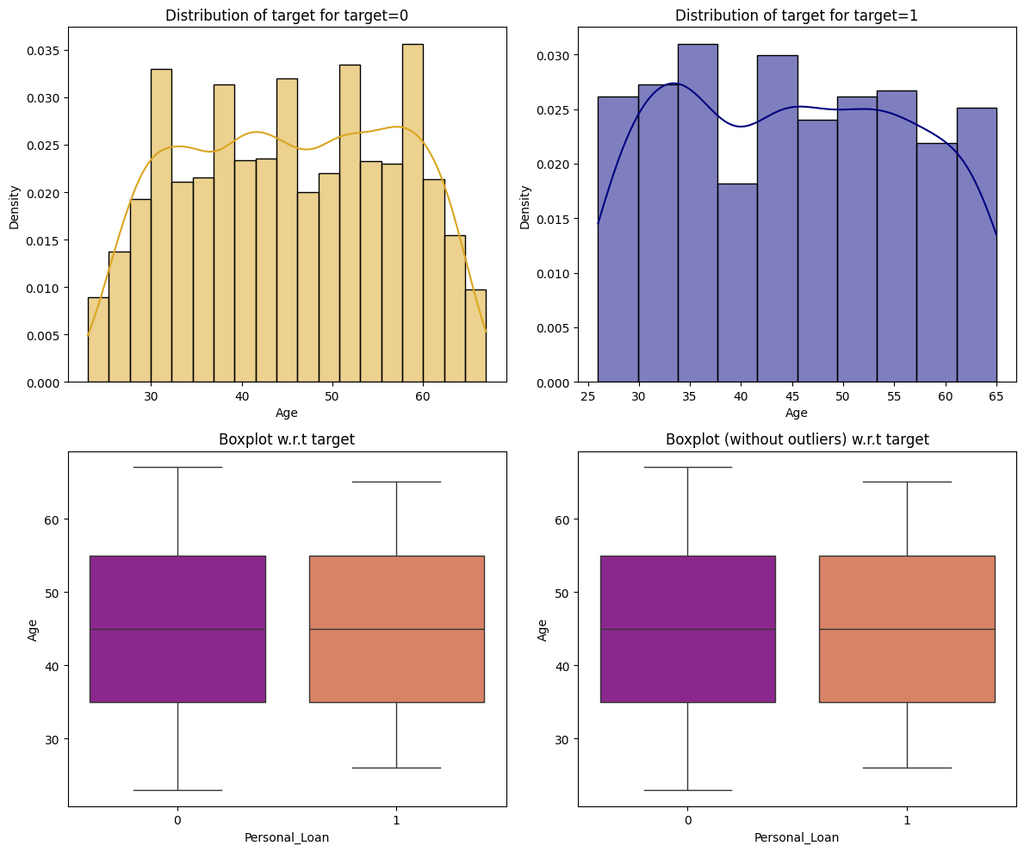

```python
distribution_plot_wrt_target(data, 'Age', 'Personal_Loan')
```

Observations: Customer's age remains consistent whether they accept or not accept the personal loan in the last campaign. The average age on all scenarios is 45 years.

**Analysis of Personal Loan vs Experience variables**

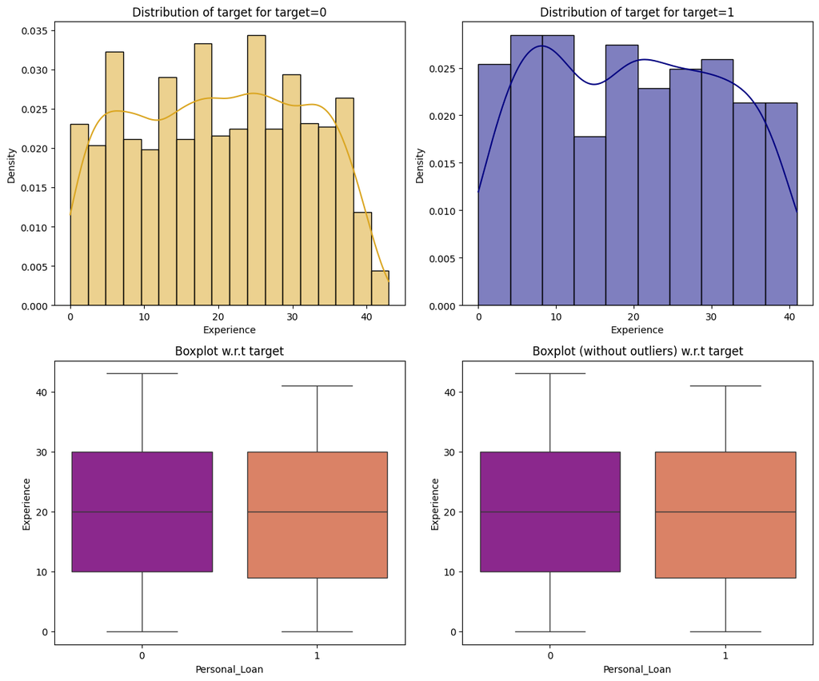

```python
distribution_plot_wrt_target(data, 'Experience', 'Personal_Loan')
```

Observations: Customer's professional experience remains consistent whether they accept or not accept the personal loan in the last campaign. The average experience on all scenarios is 20 years.

**Analysis of Personal Loan vs Income variables**

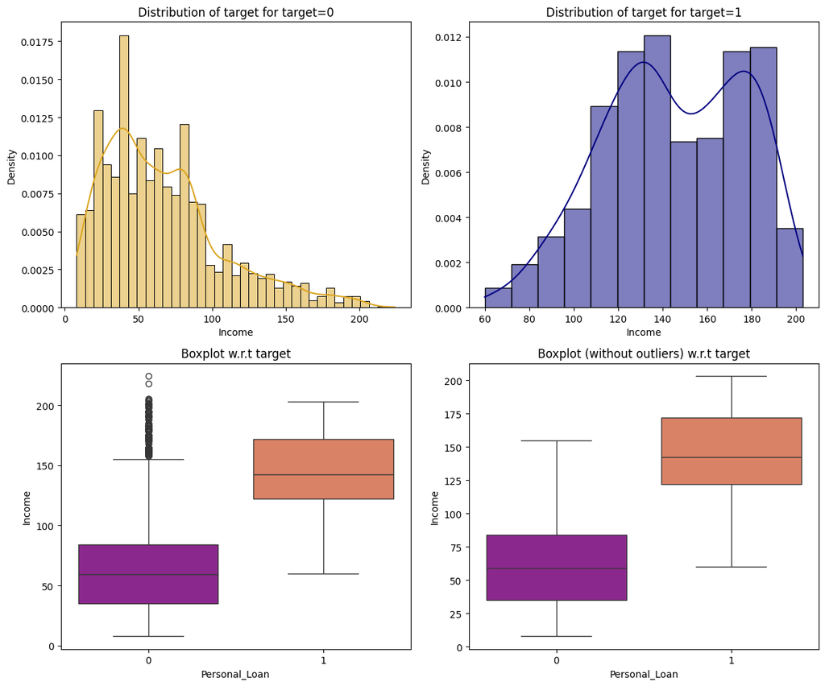

```python
distribution_plot_wrt_target(data, 'Income', 'Personal_Loan')
```

**Analysis of Personal Loan vs Zip Code variables**

```
ZIPCode         90   91   92   93    94   95  96   All
Personal_Loan
All            703  565  988  417  1472  815  40  5000
0              636  510  894  374  1334  735  37  4520
1               67   55   94   43   138   80   3   480
------------------------------------------------------------------------------------------------------------------------
```

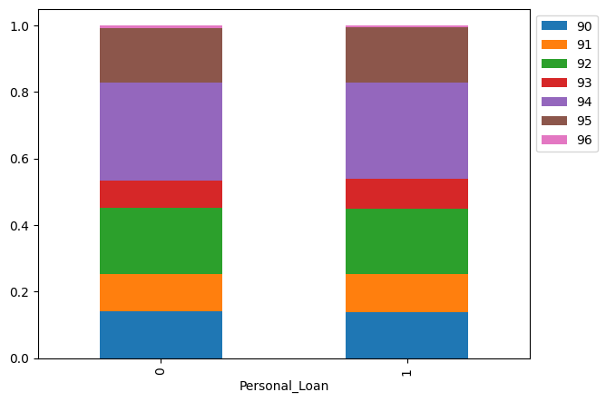

```python
stacked_barplot(data, "Personal_Loan", "ZIPCode")
```

**Analysis of Personal Loan vs Family variables**

```
Family            1     2     3     4   All
Personal_Loan
All            1472  1296  1010  1222  5000
0              1365  1190   877  1088  4520
1               107   106   133   134   480
------------------------------------------------------------------------------------------------------------------------
```

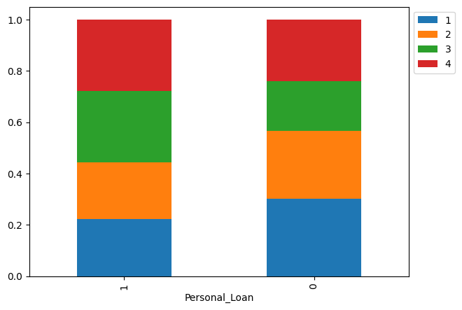

```python
stacked_barplot(data, "Personal_Loan", "Family")
```

Observations: While family sizes of 3 and 4 have the lesser amounts of offers to accept a personal loan, they have the higher volume of accepted loans (Family of 3 with 133 accepted and Family of 4 with 134 accepted).

**Analysis of Personal Loan vs Credit Card Average spending variables**

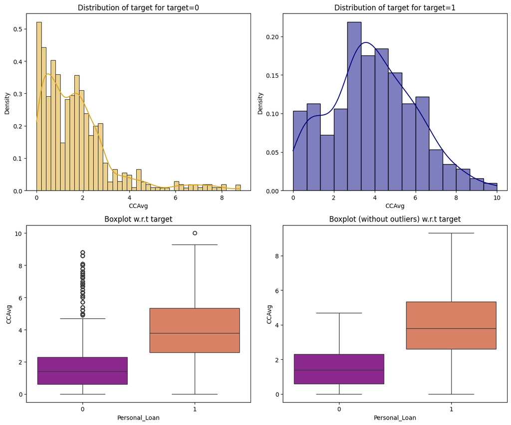

```python
distribution_plot_wrt_target(data, 'CCAvg', 'Personal_Loan')
```

Observations:

- Customers with higher credit card averages were more likely to accept a personal loan than customers with lower credit card averages.
- There are large number of outliers for customers with some of the highest average spending on credit cards that did not accept a personal loan.
- There are a small number of outliers for customers with some of the highest average spending on credit cards that did accept a personal loan.

**Analysis of Personal Loan vs Education variables**

```
Education         1     2     3   All
Personal_Loan
All            2096  1403  1501  5000
0              2003  1221  1296  4520
1                93   182   205   480
------------------------------------------------------------------------------------------------------------------------
```

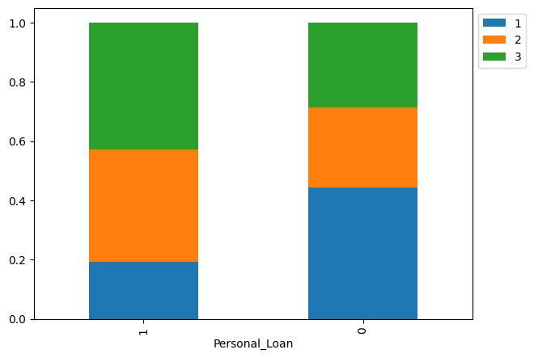

```python
stacked_barplot(data, 'Personal_Loan', 'Education')
```

Observations: Customers with higher levels of education were accepting personal loans offered in greater volume during the last campaign.

**Analysis of Personal Loan vs Mortgage variables**

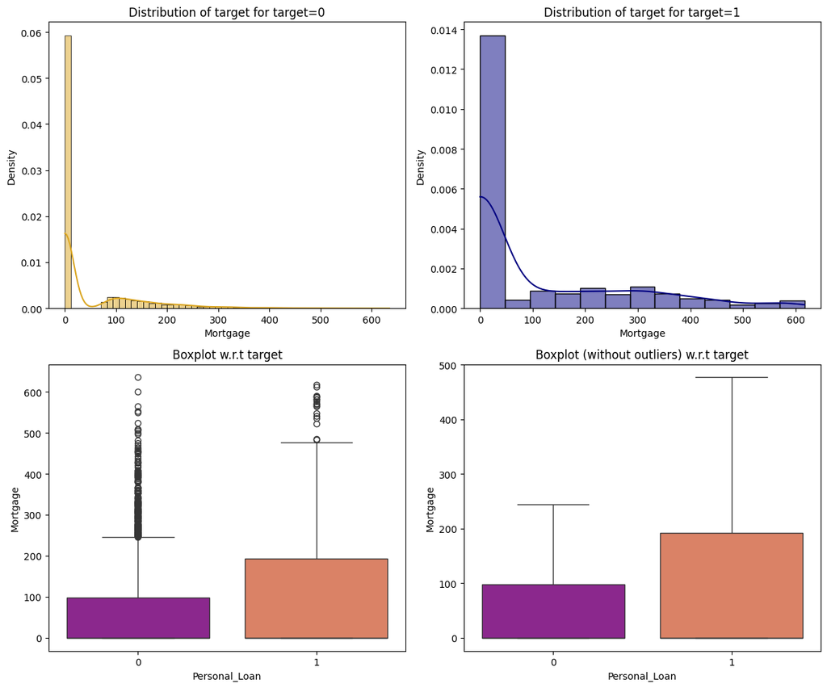

```python
distribution_plot_wrt_target(data, 'Mortgage', 'Personal_Loan')
```

**Analysis of Personal Loan vs Securities Account variables**

```
Securities_Account     0    1   All
Personal_Loan
All                 4478  522  5000
0                   4058  462  4520
1                    420   60   480
------------------------------------------------------------------------------------------------------------------------
```

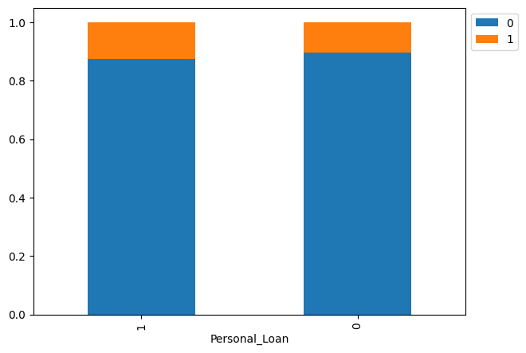

```python
stacked_barplot(data, "Personal_Loan", "Securities_Account")
```

Observations: Approximately 11% of the customers with a securities account with the bank accepted a personal loan during the last campaign.

**Analysis of Personal Loan vs CD Account variables**

```
CD_Account        0    1   All
Personal_Loan
All            4698  302  5000
0              4358  162  4520
1               340  140   480
------------------------------------------------------------------------------------------------------------------------
```

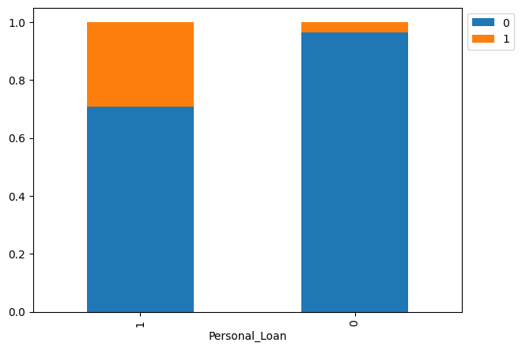

```python
stacked_barplot(data, 'Personal_Loan', 'CD_Account')
```

Observations: Approximately 46% of the customers with a Certificate of Deposit (CD) with the bank accepted a personal loan during the last campaign.

**Analysis of Personal Loan vs Online variables**

```
Online            0     1   All
Personal_Loan
All            2016  2984  5000
0              1827  2693  4520
1               189   291   480
------------------------------------------------------------------------------------------------------------------------
```

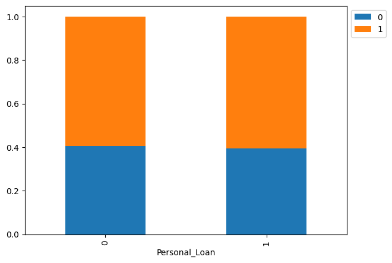

```python
stacked_barplot(data, 'Personal_Loan', 'Online')
```

Observations: There's not much difference between online vs non-online customers.

**Analysis of Personal Loan vs Credit Card variables**

```
CreditCard        0     1   All
Personal_Loan
All            3530  1470  5000
0              3193  1327  4520
1               337   143   480
------------------------------------------------------------------------------------------------------------------------
```

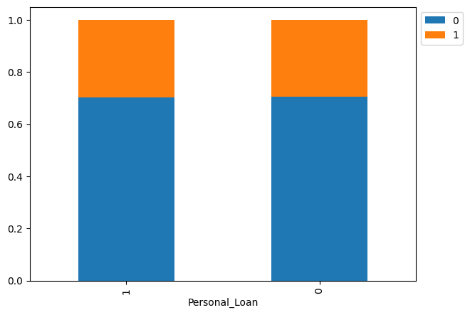

```python
stacked_barplot(data, 'Personal_Loan', 'CreditCard')
```

Observations:

- Approximately 9% of the customers with a Credit Card with another bank accepted a personal loan during the last campaign.
- Approximately 9% of the customers that did not have a Credit Card with another bank accepted a personal loan during the last campaign.

# **Data Preprocessing**

## Outlier Detection

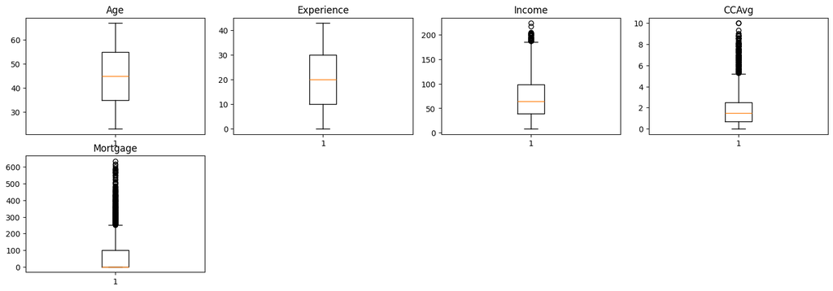

```python
# outlier detection using boxplot
numeric_columns = data.select_dtypes(include=np.number).columns.tolist()

plt.figure(figsize=(15, 10))

for i, variable in enumerate(numeric_columns):
    plt.subplot(4, 4, i + 1)
    plt.boxplot(data[variable], whis=1.5)
    plt.tight_layout()
    plt.title(variable)

plt.show()
```

Observations

- There are a number of outliers in the data.
- Will not treat them as they are proper values.

## Preparing data for modeling

```python
# define the independent and dependent variables

X = data.drop(['Personal_Loan','Experience'], axis=1) # dropping Experence as it very highly correlated to Age which is kept in the dataframe
Y = data['Personal_Loan']
```

```python
# create dummy variable

X = pd.get_dummies(X, columns=['ZIPCode', 'Education'], drop_first=True)

# specify the datatype of the independent variables data frame
X = X.astype(float)

X.head()
```

|  | Age | Income | Family | CCAvg | Mortgage | Securities_Account | CD_Account | Online | CreditCard | ZIPCode_91 | ZIPCode_92 | ZIPCode_93 | ZIPCode_94 | ZIPCode_95 | ZIPCode_96 | Education_2 | Education_3 |
| --- | --- | --- | --- | --- | --- | --- | --- | --- | --- | --- | --- | --- | --- | --- | --- | --- | --- |
| 0 | 25.0 | 49.0 | 4.0 | 1.6 | 0.0 | 1.0 | 0.0 | 0.0 | 0.0 | 1.0 | 0.0 | 0.0 | 0.0 | 0.0 | 0.0 | 0.0 | 0.0 |
| 1 | 45.0 | 34.0 | 3.0 | 1.5 | 0.0 | 1.0 | 0.0 | 0.0 | 0.0 | 0.0 | 0.0 | 0.0 | 0.0 | 0.0 | 0.0 | 0.0 | 0.0 |
| 2 | 39.0 | 11.0 | 1.0 | 1.0 | 0.0 | 0.0 | 0.0 | 0.0 | 0.0 | 0.0 | 0.0 | 0.0 | 1.0 | 0.0 | 0.0 | 0.0 | 0.0 |
| 3 | 35.0 | 100.0 | 1.0 | 2.7 | 0.0 | 0.0 | 0.0 | 0.0 | 0.0 | 0.0 | 0.0 | 0.0 | 1.0 | 0.0 | 0.0 | 1.0 | 0.0 |
| 4 | 35.0 | 45.0 | 4.0 | 1.0 | 0.0 | 0.0 | 0.0 | 0.0 | 1.0 | 1.0 | 0.0 | 0.0 | 0.0 | 0.0 | 0.0 | 1.0 | 0.0 |

```python
# splitting the data in an 70:30 ratio for train and test sets with random state = 1
X_train, X_test, y_train, y_test = train_test_split(X, Y, test_size=0.30, random_state=1)
```

```python
#print percentages of classes in training and test sets
print("Shape of Training set : ", X_train.shape)
print("Shape of test set : ", X_test.shape, '\n')
print("Percentage of classes in training set:")
print(100 * y_train.value_counts(normalize=True), '\n')
print("Percentage of classes in test set:")
print(100 * y_test.value_counts(normalize=True))
```

```
Shape of Training set :  (3500, 17)
Shape of test set :  (1500, 17)

Percentage of classes in training set:
Personal_Loan
0    90.542857
1     9.457143
Name: proportion, dtype: float64

Percentage of classes in test set:
Personal_Loan
0    90.066667
1     9.933333
Name: proportion, dtype: float64
```